# Phenotyping menstrual breast pain from large-scale self-tracked data

Laura Symul, Paula Hillard and Susan Holmes

2019

# Abstract

**Background**

Millions of women are now using smartphone apps to track their menstrual cycles and associated symptoms, such as mastalgia (breast tenderness and pain). Breast tenderness is described as painful or uncomfortable sensations in the breast, sometimes with a change of volume or consistency of the breasts themselves. The prevalence, intensity, timing and duration of mastalgia have not been optimally characterized. For many women there is a cyclic association with the menstrual cycle indicating a hormonal association, although the specific causes of pain are not well established.

**Objectives**

To describe the prevalence, timing and duration of breast pain symptoms as reported by users of a menstrual cycle tracking app, and to evaluate changes in reported symptoms at birth control transitions.

**Methods**

We analyzed a retrospective dataset of 216,484 ¬users of the Clue app with over 4.5 million self-reports of “tender breasts”. Tracking behavior of users was characterized on a per-cycle basis and clustered into typical app usages. Symptoms reported by regular app users were further characterized with four distinct metrics, i.e. symptom timing, duration, cyclicity and variability from one cycle to the next. Birth control method was determined based on the users self-declared report, on their menstrual characteristics and on their pill-intake logs if any.

**Results**

This study confirms associations between steroid hormonal use and breast pain symptoms. It also shows that most affected users experience specific and consistent symptom patterns, which may reflect their underlying hormonal profiles or tissue-specific response. These woman-specific patterns have yet to be correlated with temporal bio-markers profiles or breast exam results to further advance our understanding of the mastalgia causes.

# Figures

## Figure 1

Data collection, Dataset, Tracking behavior and Aggregated Reported Symptoms of Breast Tenderness

[figure not shown]

## Supplementary Figure

Breast tenderness predictors

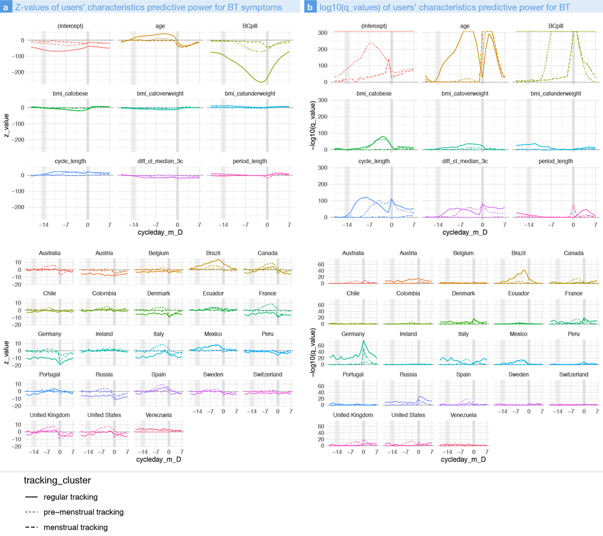

## Figure 2

Breast tenderness phenotypes

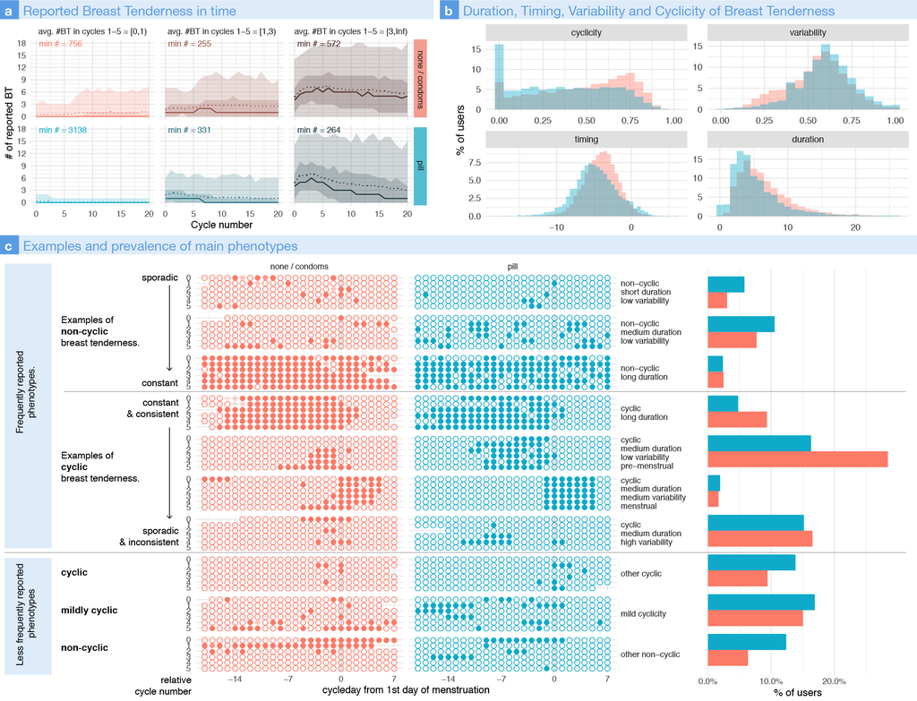

## Figure 3

Breast Tenderness at pill transitions

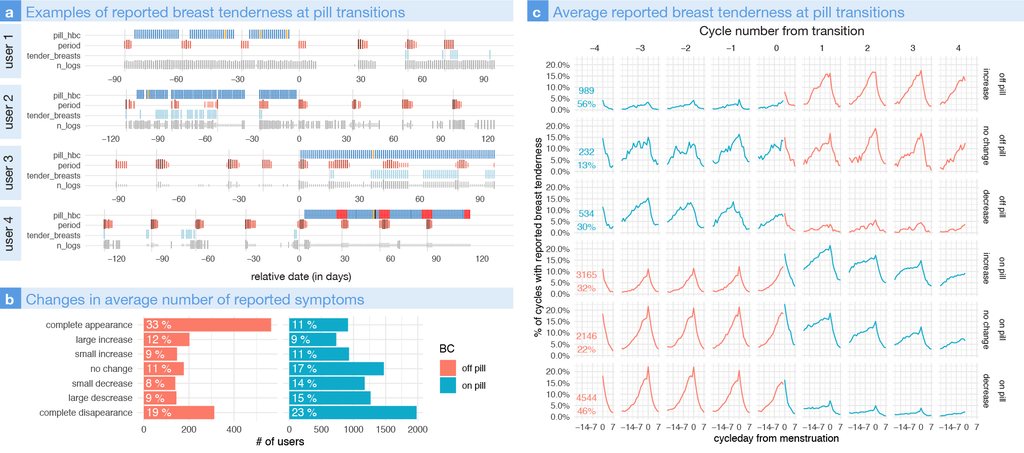

# Code and Data

Code and aggregated data to reproduce the figures can be found and downloaded on the github repo TB-Public-Repo .

Specifically, click [here](https://lasy.github.io/TB-Public-Repo/Code/Tender_breasts_FIGURES.html) for the rendered Rmd (R code // R markdown) used to generate the Figures.

This link will bring you to the rendered R markdown for the full analysis of the data: [Analysis](https://lasy.github.io/TB-Public-Repo/Code/Tender_breasts_ANALYSIS.html)

# Contact

Any question or request can be addressed at Laura Symul

lsymul@stanford.edu

laurasymul@gmail.com

[lsy.works](http://lsy.works/)

[twitter](https://twitter.com/LauraSymul) @LauraSymul

[figure not shown]